# GIS 3 Data processing for original input files

# Purpose of file

This is the very first file in the coding workflow for the project. I’ve gathered data on pokemon spawn points, census tract polygons, census tract attributes, locations of restaurants, etc.

But these need extensive data cleaning and some spatial computations (e.g. to get total number of bike trip destinations by location). The results will be saved in GIS3SpatialRawData folder.

# Step 0: Libraries

```r
library(tidyverse)
library(sf)
library(RColorBrewer)
library(tmap)
setwd("~/Desktop/GIS3FinalProject")
```

# Step 1: Process pokemon points

## Step 1.1 Load in raw pokemon data

```r
pokemon_raw <- read.csv("./GIS3RawData/pokemon-spawns.csv")
head(pokemon_raw)
```

|  | s2_id | s2_token | num | name | lat | lng | encounter_ms | disppear_ms |
| --- | --- | --- | --- | --- | --- | --- | --- | --- |
| 1 | -9.185795e+18 | 8085808cc6d | 13 | Weedle | 37.79359 | -122.4087 | 1469520187732 | 1.46952e+12 |
| 2 | -9.185795e+18 | 8085808b51d | 16 | Pidgey | 37.79475 | -122.4064 | 1469520297172 | 1.46952e+12 |
| 3 | -9.185795e+18 | 8085808b271 | 41 | Zubat | 37.79500 | -122.4044 | 1469520709924 | 1.46952e+12 |
| 4 | -9.185794e+18 | 808580f3587 | 16 | Pidgey | 37.79564 | -122.4071 | -1 | 1.46952e+12 |
| 5 | -9.185794e+18 | 808580f4b1d | 60 | Poliwag | 37.79559 | -122.4063 | 1469520741876 | 1.46952e+12 |
| 6 | -9.182922e+18 | 808fb4e54b3 | 50 | Diglett | 37.30113 | -122.0485 | 1469520163692 | 1.46952e+12 |

```r
str(pokemon_raw)
```

```
'data.frame':   314105 obs. of  8 variables:
 $ s2_id       : num  -9.19e+18 -9.19e+18 -9.19e+18 -9.19e+18 -9.19e+18 ...
 $ s2_token    : chr  "8085808cc6d" "8085808b51d" "8085808b271" "808580f3587" ...
 $ num         : int  13 16 41 16 60 50 23 41 46 41 ...
 $ name        : chr  "Weedle" "Pidgey" "Zubat" "Pidgey" ...
 $ lat         : num  37.8 37.8 37.8 37.8 37.8 ...
 $ lng         : num  -122 -122 -122 -122 -122 ...
 $ encounter_ms: num  1.47e+12 1.47e+12 1.47e+12 -1.00 1.47e+12 ...
 $ disppear_ms : num  1.47e+12 1.47e+12 1.47e+12 1.47e+12 1.47e+12 ...
```

## Step 1.2: Process raw pokemon data to have spatial long lat, and count number of pokemons at each point

```r
pokemon_processing <- pokemon_raw
colnames(pokemon_processing)
```

```
[1] "s2_id"        "s2_token"     "num"          "name"         "lat"
[6] "lng"          "encounter_ms" "disppear_ms"
```

```r
pokemon_processing$lat <- as.numeric(pokemon_processing$lat)
pokemon_processing$lng <- as.numeric(pokemon_processing$lng)
pokemon_processing
```

| s2_id | s2_token | num | name | lat | lng | encounter_ms | disppear_ms |
| --- | --- | --- | --- | --- | --- | --- | --- |
| -9.185795e+18 | 8085808cc6d | 13 | Weedle | 37.79359 | -122.4087 | 1469520187732 | 1.46952e+12 |
| -9.185795e+18 | 8085808b51d | 16 | Pidgey | 37.79475 | -122.4064 | 1469520297172 | 1.46952e+12 |
| -9.185795e+18 | 8085808b271 | 41 | Zubat | 37.79500 | -122.4044 | 1469520709924 | 1.46952e+12 |
| -9.185794e+18 | 808580f3587 | 16 | Pidgey | 37.79564 | -122.4071 | -1 | 1.46952e+12 |
| -9.185794e+18 | 808580f4b1d | 60 | Poliwag | 37.79559 | -122.4063 | 1469520741876 | 1.46952e+12 |
| -9.182922e+18 | 808fb4e54b3 | 50 | Diglett | 37.30113 | -122.0485 | 1469520163692 | 1.46952e+12 |
| -9.182922e+18 | 808fb4e4ea1 | 23 | Ekans | 37.30076 | -122.0457 | 1469520356612 | 1.46952e+12 |
| -9.182922e+18 | 808fb4faf4d | 41 | Zubat | 37.30346 | -122.0482 | 1469520502676 | 1.46952e+12 |
| -9.182982e+18 | 808f7e1799d | 46 | Paras | 37.75947 | -122.4262 | 1469520422772 | 1.46952e+12 |
| -9.182982e+18 | 808f7e3d705 | 41 | Zubat | 37.75950 | -122.4232 | 1469520349332 | 1.46952e+12 |

[output cut: 990 more lines]

```r
pokemon_point_counts <-
  pokemon_processing %>%
  group_by(lat, lng) %>%
  summarize(NumPokemon = n()) %>%
  rename(long='lng') %>%
  arrange(long, lat)
pokemon_point_counts$AllPokeLocID <- 1:nrow(pokemon_point_counts)

pokemon_point_counts <-
  pokemon_point_counts %>%
  relocate(AllPokeLocID, .before=lat) %>%
  relocate(lat, .after=long)

pokemon_point_counts %>% arrange(long)
```

| AllPokeLocID | long | lat | NumPokemon |
| --- | --- | --- | --- |
| 1 | -122.6118 | 37.83642 | 3 |
| 2 | -122.6112 | 37.83862 | 4 |
| 3 | -122.6110 | 37.83867 | 4 |
| 4 | -122.6106 | 37.83873 | 3 |
| 5 | -122.6099 | 37.85653 | 4 |
| 6 | -122.6097 | 37.84064 | 5 |
| 7 | -122.6096 | 37.83881 | 4 |
| 8 | -122.6084 | 37.83882 | 4 |
| 9 | -122.6079 | 37.89324 | 2 |
| 10 | -122.6076 | 37.89409 | 3 |

[output cut: 990 more lines]

```r
pokemon_point_counts %>% arrange(-long)
```

| AllPokeLocID | long | lat | NumPokemon |
| --- | --- | --- | --- |
| 89083 | 139.8405 | 35.67812 | 1 |
| 89084 | 139.8405 | 35.70589 | 1 |
| 89080 | 139.8404 | 35.64031 | 1 |
| 89081 | 139.8404 | 35.65496 | 1 |
| 89082 | 139.8404 | 35.71160 | 1 |
| 89075 | 139.8403 | 35.67360 | 1 |
| 89076 | 139.8403 | 35.68164 | 1 |
| 89077 | 139.8403 | 35.68193 | 2 |
| 89078 | 139.8403 | 35.70626 | 1 |
| 89079 | 139.8403 | 35.71423 | 2 |

[output cut: 990 more lines]

```r
pokemon_point_counts_sf <- st_as_sf(pokemon_point_counts, coords = c("long", "lat"), crs=4326)
```

# Step 2: Process San Francisco 2010 census tracts

## 2.1 Load polygon file of census tracts

```r
SanFran_tracts <- st_read('./GIS3RawData/SF2010Tracts.geojson')
head(SanFran_tracts)
```

```
Simple feature collection with 6 features and 12 fields
geometry type:  MULTIPOLYGON
dimension:      XY
bbox:           xmin: -122.4547 ymin: 37.77193 xmax: -122.4202 ymax: 37.78544
geographic CRS: WGS 84
  statefp10 mtfcc10 name10  intptlat10 awater10       namelsad10 funcstat10
1        06   G5020    165 +37.7741958        0 Census Tract 165          S
2        06   G5020    164 +37.7750995        0 Census Tract 164          S
3        06   G5020    163 +37.7760456        0 Census Tract 163          S
4        06   G5020    161 +37.7799831        0 Census Tract 161          S
5        06   G5020    160 +37.7823363        0 Census Tract 160          S
6        06   G5020    159 +37.7833400        0 Census Tract 159          S
  aland10     geoid10 tractce10   intptlon10 countyfp10
1  370459 06075016500    016500 -122.4477884        075
2  309097 06075016400    016400 -122.4369729        075
3  245867 06075016300    016300 -122.4295509        075
4  368901 06075016100    016100 -122.4286631        075
5  158236 06075016000    016000 -122.4224838        075
6  295388 06075015900    015900 -122.4293428        075
                        geometry
1 MULTIPOLYGON (((-122.4465 3...
2 MULTIPOLYGON (((-122.4403 3...
3 MULTIPOLYGON (((-122.4292 3...
4 MULTIPOLYGON (((-122.4289 3...
5 MULTIPOLYGON (((-122.4204 3...
6 MULTIPOLYGON (((-122.4323 3...
```

## 2.2 Setting EPSGs and joining pokemon spawn points with counts to San Francisco tracts so that each row (point) is assigned a tract

```r
pokemon_point_counts_7132 <- pokemon_point_counts_sf %>% st_transform(7132)
SanFran_tracts_7132 <- SanFran_tracts %>% st_transform(7132)

pokemon_point_counts_SanFran <-
  st_join(pokemon_point_counts_7132,
          SanFran_tracts_7132, join = st_within, left=FALSE) %>%
  select(AllPokeLocID, NumPokemon, geometry, geoid10)

pokemon_point_counts_SanFran$geoid10 <- as.numeric(pokemon_point_counts_SanFran$geoid10)
pokemon_point_counts_SanFran <-
  pokemon_point_counts_SanFran %>% rename(GeoFIPS = 'geoid10')

head(pokemon_point_counts_SanFran)
```

```
Simple feature collection with 6 features and 3 fields
geometry type:  POINT
dimension:      XY
bbox:           xmin: 135755.6 ymin: 73542.78 xmax: 137696 ymax: 105359.2
projected CRS:  NAD83(2011) / San Francisco CS13 (ftUS)
```

| AllPokeLocID | NumPokemon | geometry | GeoFIPS |
| --- | --- | --- | --- |
| 622 | 1 |  | 6075990100 |
| 626 | 2 |  | 6075060100 |
| 646 | 2 |  | 6075990100 |
| 658 | 2 |  | 6075060100 |
| 686 | 1 |  | 6075060100 |
| 707 | 3 |  | 6075060100 |

```r
unioned_pokemon_point_counts_SanFran <-
  st_union(pokemon_point_counts_SanFran)

relevant_SanFran_tracts_7132 <-
  SanFran_tracts_7132 %>%
  filter(st_intersects(., unioned_pokemon_point_counts_SanFran, sparse=FALSE)) %>%
  mutate(GeoFIPS = as.numeric(geoid10))

relevant_SanFran_tracts_7132
```

```
Simple feature collection with 196 features and 13 fields
geometry type:  MULTIPOLYGON
dimension:      XY
bbox:           xmin: 110597.9 ymin: 63004.3 xmax: 206146.7 ymax: 144224
projected CRS:  NAD83(2011) / San Francisco CS13 (ftUS)
First 10 features:
   statefp10 mtfcc10 name10  intptlat10 awater10       namelsad10 funcstat10
1         06   G5020    165 +37.7741958        0 Census Tract 165          S
2         06   G5020    164 +37.7750995        0 Census Tract 164          S
3         06   G5020    163 +37.7760456        0 Census Tract 163          S
4         06   G5020    161 +37.7799831        0 Census Tract 161          S
5         06   G5020    160 +37.7823363        0 Census Tract 160          S
6         06   G5020    159 +37.7833400        0 Census Tract 159          S
7         06   G5020    157 +37.7789154        0 Census Tract 157          S
8         06   G5020    156 +37.7782427        0 Census Tract 156          S
```

[output cut: 24 more lines]

## 2.3 Find only relevant tracts that have pokemon points

```r
# Union individual points to one object so that we can intersect tracts with this point object
unioned_pokemon_point_counts_SanFran <-
  st_union(pokemon_point_counts_SanFran)

# Select only tracts that actually have points
relevant_SanFran_tracts_7131 <-
  SanFran_tracts_7131 %>%
  filter(st_intersects(., unioned_pokemon_point_counts_SanFran, sparse=FALSE)) %>%
  mutate(GeoFIPS = as.numeric(geoid10))

relevant_SanFran_tracts_7131
```

## 2.4 Quick tmap visualization of number of pokemon at each point, and only in census tracts that actually have points

```r
#SanFran_tracts_7132

nrow(relevant_SanFran_tracts_7132)
```

```
[1] 196
```

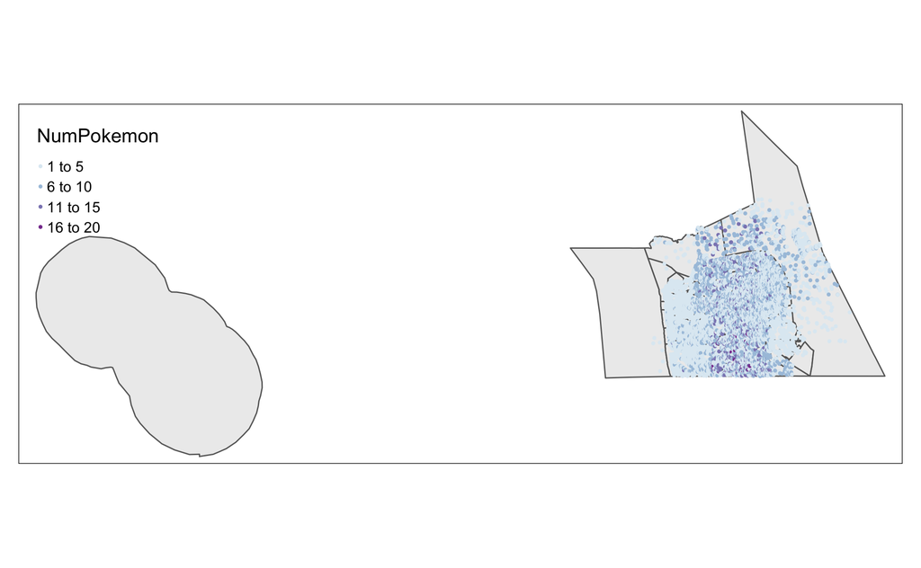

```r
tm_shape(SanFran_tracts_7132) +
  tm_polygons(alpha=0.5) +
tm_shape(pokemon_point_counts_SanFran) +
  tm_dots(col='NumPokemon', pal='BuPu')
```

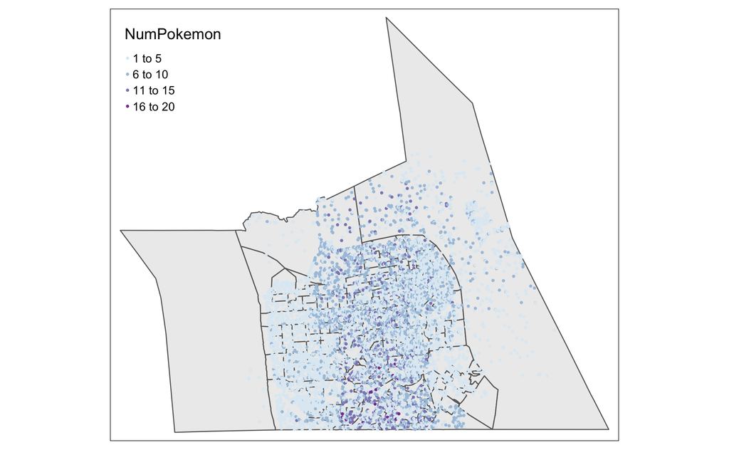

```r
tm_shape(relevant_SanFran_tracts_7132) +
  tm_polygons(alpha=0.5) +
tm_shape(pokemon_point_counts_SanFran) +
  tm_dots(col='NumPokemon', pal='BuPu')
```

# Step 3: Wrangle Census data

## 3.1 Load in raw census socioeconomic data

```r
SanFran_ACS_raw <- read.csv("./GIS3RawData/SanFranACS.csv")
SanFran_ACS_raw
```

| Geo_FIPS | Geo_GEOID | Geo_NAME | Geo_QName | Geo_STUSAB | Geo_SUMLEV | Geo_GEOCOMP | Geo_FILEID | Geo_LOGRECNO | Geo_US | Geo_REGION | Geo_DIVISION | Geo_STATECE | Geo_STATE | Geo_COUNTY | Geo_COUSUB | Geo_PLACE | Geo_PLACESE | Geo_TRACT | Geo_BLKGRP | Geo_CONCIT | Geo_AIANHH | Geo_AIANHHFP | Geo_AIHHTLI | Geo_AITSCE | Geo_AITS | Geo_ANRC | Geo_CBSA | Geo_CSA | Geo_METDIV | … |
| --- | --- | --- | --- | --- | --- | --- | --- | --- | --- | --- | --- | --- | --- | --- | --- | --- | --- | --- | --- | --- | --- | --- | --- | --- | --- | --- | --- | --- | --- | --- |
| 6075010100 | 14000US06075010100 | Census Tract 101 | Census Tract 101, San Francisco County, California | ca | 140 | 0 | ACSSF | 8986 | NA | NA | NA | NA | 6 | 75 | NA | NA | NA | 10100 | NA | NA | NA | NA | NA | NA | NA | NA | NA | NA | NA | … |
| 6075010200 | 14000US06075010200 | Census Tract 102 | Census Tract 102, San Francisco County, California | ca | 140 | 0 | ACSSF | 8987 | NA | NA | NA | NA | 6 | 75 | NA | NA | NA | 10200 | NA | NA | NA | NA | NA | NA | NA | NA | NA | NA | NA | … |
| 6075010300 | 14000US06075010300 | Census Tract 103 | Census Tract 103, San Francisco County, California | ca | 140 | 0 | ACSSF | 8988 | NA | NA | NA | NA | 6 | 75 | NA | NA | NA | 10300 | NA | NA | NA | NA | NA | NA | NA | NA | NA | NA | NA | … |
| 6075010400 | 14000US06075010400 | Census Tract 104 | Census Tract 104, San Francisco County, California | ca | 140 | 0 | ACSSF | 8989 | NA | NA | NA | NA | 6 | 75 | NA | NA | NA | 10400 | NA | NA | NA | NA | NA | NA | NA | NA | NA | NA | NA | … |
| 6075010500 | 14000US06075010500 | Census Tract 105 | Census Tract 105, San Francisco County, California | ca | 140 | 0 | ACSSF | 8990 | NA | NA | NA | NA | 6 | 75 | NA | NA | NA | 10500 | NA | NA | NA | NA | NA | NA | NA | NA | NA | NA | NA | … |
| 6075010600 | 14000US06075010600 | Census Tract 106 | Census Tract 106, San Francisco County, California | ca | 140 | 0 | ACSSF | 8991 | NA | NA | NA | NA | 6 | 75 | NA | NA | NA | 10600 | NA | NA | NA | NA | NA | NA | NA | NA | NA | NA | NA | … |
| 6075010700 | 14000US06075010700 | Census Tract 107 | Census Tract 107, San Francisco County, California | ca | 140 | 0 | ACSSF | 8992 | NA | NA | NA | NA | 6 | 75 | NA | NA | NA | 10700 | NA | NA | NA | NA | NA | NA | NA | NA | NA | NA | NA | … |
| 6075010800 | 14000US06075010800 | Census Tract 108 | Census Tract 108, San Francisco County, California | ca | 140 | 0 | ACSSF | 8993 | NA | NA | NA | NA | 6 | 75 | NA | NA | NA | 10800 | NA | NA | NA | NA | NA | NA | NA | NA | NA | NA | NA | … |
| 6075010900 | 14000US06075010900 | Census Tract 109 | Census Tract 109, San Francisco County, California | ca | 140 | 0 | ACSSF | 8994 | NA | NA | NA | NA | 6 | 75 | NA | NA | NA | 10900 | NA | NA | NA | NA | NA | NA | NA | NA | NA | NA | NA | … |
| 6075011000 | 14000US06075011000 | Census Tract 110 | Census Tract 110, San Francisco County, California | ca | 140 | 0 | ACSSF | 8995 | NA | NA | NA | NA | 6 | 75 | NA | NA | NA | 11000 | NA | NA | NA | NA | NA | NA | NA | NA | NA | NA | NA | … |

[output cut: 187 more lines]

## 3.2 Rename and mutate census variables to more intuitive names

```r
SanFran_ACS_renamed <-
  SanFran_ACS_raw %>%
  select(Geo_FIPS, Geo_GEOID, Geo_NAME,
         tpop = SE_A01001_001,
         pden = SE_A00002_002,
         apop = SE_A03001_005,
         bpop = SE_A03001_003,
         hpop = SE_A04001_010,
         uemp = SE_A17005_003 / SE_A17005_001,
         pinc = SE_A14024_001,
         ag_rent = SE_A18005_001, # avg gross rent
         commute = SE_A09003_001 # commute time
         ) %>%
  mutate(aprp = apop/tpop, bprp = bpop/tpop, hprp = hpop / tpop) %>%
  mutate(minoprp = aprp + bprp + hprp) %>%
  relocate(minoprp, .before= aprp) %>%
  select(-apop, -bpop, -hpop) %>%
  rename(GeoFIPS = 'Geo_FIPS') %>%
  mutate(GeoFIPS = as.numeric(GeoFIPS)) %>%
  filter(GeoFIPS %in% relevant_SanFran_tracts_7132$GeoFIPS)

SanFran_ACS_renamed
```

[output not shown]

[output cut: 186 more lines]

## 3.3 Merge pokemon points with census tract attributes with the census tract data, so that each point is assigned census tract variable columns (e.g. population density)

```r
pokemon_point_counts_SanFran_ACS <-
  merge(pokemon_point_counts_SanFran, SanFran_ACS_renamed, all.x=TRUE,
        by='GeoFIPS')
  # a few census tracts without ACS

length(unique(pokemon_point_counts_SanFran$GeoFIPS))
```

```
[1] 196
```

```r
data.frame(pokemon_point_counts_SanFran_ACS) %>% arrange(-GeoFIPS)
```

| GeoFIPS | AllPokeLocID | NumPokemon | Geo_GEOID | Geo_NAME | tpop | pden | uemp | pinc | ag_rent | commute | minoprp | aprp | bprp | hprp | geometry |
| --- | --- | --- | --- | --- | --- | --- | --- | --- | --- | --- | --- | --- | --- | --- | --- |
| 6075990100 | 622 | 1 | 14000US06075990100 | Census Tract 9901 | 0 | NA | 0 | NA | NA | NA | NaN | NaN | NaN | NaN |  |
| 6075990100 | 790 | 4 | 14000US06075990100 | Census Tract 9901 | 0 | NA | 0 | NA | NA | NA | NaN | NaN | NaN | NaN |  |
| 6075990100 | 646 | 2 | 14000US06075990100 | Census Tract 9901 | 0 | NA | 0 | NA | NA | NA | NaN | NaN | NaN | NaN |  |
| 6075990100 | 725 | 4 | 14000US06075990100 | Census Tract 9901 | 0 | NA | 0 | NA | NA | NA | NaN | NaN | NaN | NaN |  |
| 6075990100 | 715 | 4 | 14000US06075990100 | Census Tract 9901 | 0 | NA | 0 | NA | NA | NA | NaN | NaN | NaN | NaN |  |
| 6075990100 | 815 | 3 | 14000US06075990100 | Census Tract 9901 | 0 | NA | 0 | NA | NA | NA | NaN | NaN | NaN | NaN |  |
| 6075980900 | 14790 | 3 | 14000US06075980900 | Census Tract 9809 | 253 | 182.76790 | 0 | 56873 | 2349.2308 | 42 | 0.48221344 | 0.22134387 | 0.071146245 | 0.189723320 |  |
| 6075980900 | 15117 | 1 | 14000US06075980900 | Census Tract 9809 | 253 | 182.76790 | 0 | 56873 | 2349.2308 | 42 | 0.48221344 | 0.22134387 | 0.071146245 | 0.189723320 |  |
| 6075980900 | 13913 | 1 | 14000US06075980900 | Census Tract 9809 | 253 | 182.76790 | 0 | 56873 | 2349.2308 | 42 | 0.48221344 | 0.22134387 | 0.071146245 | 0.189723320 |  |
| 6075980900 | 14921 | 2 | 14000US06075980900 | Census Tract 9809 | 253 | 182.76790 | 0 | 56873 | 2349.2308 | 42 | 0.48221344 | 0.22134387 | 0.071146245 | 0.189723320 |  |

[output cut: 990 more lines]

```r
data.frame(pokemon_point_counts_SanFran_ACS) %>% drop_na()
```

| GeoFIPS | AllPokeLocID | NumPokemon | Geo_GEOID | Geo_NAME | tpop | pden | uemp | pinc | ag_rent | commute | minoprp | aprp | bprp | hprp | geometry |
| --- | --- | --- | --- | --- | --- | --- | --- | --- | --- | --- | --- | --- | --- | --- | --- |
| 6075010100 | 12046 | 7 | 14000US06075010100 | Census Tract 101 | 3889 | 12971.790 | 87 | 52552 | 1688.3145 | 29 | 0.5772692 | 0.39444587 | 0.060683980 | 0.12213937 |  |
| 6075010100 | 12540 | 5 | 14000US06075010100 | Census Tract 101 | 3889 | 12971.790 | 87 | 52552 | 1688.3145 | 29 | 0.5772692 | 0.39444587 | 0.060683980 | 0.12213937 |  |
| 6075010100 | 12639 | 4 | 14000US06075010100 | Census Tract 101 | 3889 | 12971.790 | 87 | 52552 | 1688.3145 | 29 | 0.5772692 | 0.39444587 | 0.060683980 | 0.12213937 |  |
| 6075010100 | 12218 | 4 | 14000US06075010100 | Census Tract 101 | 3889 | 12971.790 | 87 | 52552 | 1688.3145 | 29 | 0.5772692 | 0.39444587 | 0.060683980 | 0.12213937 |  |
| 6075010100 | 12551 | 6 | 14000US06075010100 | Census Tract 101 | 3889 | 12971.790 | 87 | 52552 | 1688.3145 | 29 | 0.5772692 | 0.39444587 | 0.060683980 | 0.12213937 |  |
| 6075010100 | 10763 | 8 | 14000US06075010100 | Census Tract 101 | 3889 | 12971.790 | 87 | 52552 | 1688.3145 | 29 | 0.5772692 | 0.39444587 | 0.060683980 | 0.12213937 |  |
| 6075010100 | 10875 | 7 | 14000US06075010100 | Census Tract 101 | 3889 | 12971.790 | 87 | 52552 | 1688.3145 | 29 | 0.5772692 | 0.39444587 | 0.060683980 | 0.12213937 |  |
| 6075010100 | 12648 | 4 | 14000US06075010100 | Census Tract 101 | 3889 | 12971.790 | 87 | 52552 | 1688.3145 | 29 | 0.5772692 | 0.39444587 | 0.060683980 | 0.12213937 |  |
| 6075010100 | 12002 | 4 | 14000US06075010100 | Census Tract 101 | 3889 | 12971.790 | 87 | 52552 | 1688.3145 | 29 | 0.5772692 | 0.39444587 | 0.060683980 | 0.12213937 |  |
| 6075010100 | 12091 | 5 | 14000US06075010100 | Census Tract 101 | 3889 | 12971.790 | 87 | 52552 | 1688.3145 | 29 | 0.5772692 | 0.39444587 | 0.060683980 | 0.12213937 |  |

[output cut: 990 more lines]

# Step 4: Cleaning data on location of “posh” restaurants in San Fran

Posh restaurants include boba shops, coffee shops, etc. Not just usual cheap restaurants.

## 4.1 Load posh restaurant data

```r
posh_restaurants_raw <- read.csv("./GIS3RawData/core_poi.csv")

posh_restaurants_raw
```

## 4.2 Convert posh restaraunt data into spatial format

```r
posh_restaurants_processing <- posh_restaurants_raw
posh_restaurants_processing <-
  posh_restaurants_processing %>%
  select(placekey, location_name, lat = latitude, long=longitude)

posh_restaurants_points <-
   st_as_sf(posh_restaurants_processing, coords=c('long','lat'), crs=4326)
```

## Step 5: Clean data on general restaurants in San Fran

## 5.1 Load general restaurant data

```r
restaurants_raw <-
  read.csv("./GIS3RawData/restaurant-scores-lives-standard.csv")
```

## 5.2 Convert restaurant csv data to points via long lat

```r
restaurants_processing <-
  restaurants_raw %>%
  select(business_id, business_name, long = business_longitude, lat = business_latitude) %>%
  drop_na()

restaurants_points <-
  st_as_sf(restaurants_processing, coords=c('long','lat'), crs=4326)

head(data.frame(restaurants_points))
tm_shape(relevant_SanFran_tracts_7132) +
  tm_polygons(alpha=0.5) +
tm_shape(restaurants_points) +
  tm_dots(col='blue')
```

# Step 6: Process traffic density (San Fran Lyft wheel bike rides) data

## 6.1 Load in the traffic density data

```r
bike_trips <- read.csv("./GIS3RawData/201906-baywheels-tripdata.csv")
head(bike_trips)
```

## 6.2 Aggregate trips to trips by destination, and convert to csv

```r
trips_by_destination =
  bike_trips %>%
  group_by(end_station_id, end_station_longitude, end_station_latitude) %>%
  summarize(num_trips = n()) %>%
  rename(end_long = 'end_station_longitude', end_lat = 'end_station_latitude')

trips_by_destination

trips_by_destination_points <-
  st_as_sf(trips_by_destination, coords=c('end_long','end_lat'), crs=4326)

tm_shape(relevant_SanFran_tracts_7132) +
  tm_polygons(alpha=0.5) +
tm_shape(trips_by_destination_points) +
  tm_dots(col='red')
```

# Step 7: Wrangling college location data

## 7.1 Load college data

```r
colleges_raw <- read.csv("./GIS3RawData/Map_of_Colleges_in_San_Francisco__2011_.csv")
head(colleges_raw)
```

## 7.2 Convert college location data into spatial long lat format

```r
colleges_processing <- colleges_raw
str(colleges_processing)

# String wrangling to convert Location column into long lat
colleges_processing$Location <-
  gsub("\\(", "", colleges_processing$Location)
colleges_processing$Location <-
  gsub("\\)", "", colleges_processing$Location)
colleges_processing$Location <-
  gsub(" ", "", colleges_processing$Location)

colleges_processing

colleges_processing <-
  separate(data = colleges_processing,
           col = Location, into = c("lat", "long"), sep = ",")

colleges_processing$long <- as.numeric(as.character(colleges_processing$long))
colleges_processing$lat <- as.numeric(as.character(colleges_processing$lat))

colleges_processing <-
  colleges_processing %>% select(ID, Institution, long, lat) %>% drop_na()

head(colleges_processing)
summary(colleges_processing)

# Final save of college points
colleges_points <-
  st_as_sf(colleges_processing, coords = c('long', 'lat'), crs = 4326) %>%
  st_transform(4326)

head(data.frame(colleges_points))

plot(colleges_points)
```

# Step 8: Transform all cleaned data files into EPSG 4326

```r
# Polygons of tracts that contain pokemon spawn points
relevant_SanFran_tracts_4326 <-
  relevant_SanFran_tracts_7131 %>% st_transform(4326)

st_write(relevant_SanFran_tracts_4326, "./GIS3SpatialRawData/RelevantSanFranTracts4326.geojson")

# Polygons of pokemon spawn points with pokemon spawn count and census tract attributes
pokemon_point_counts_SanFran_ACS <-
  pokemon_point_counts_SanFran_ACS %>% st_transform(4326)

st_write(pokemon_point_counts_SanFran_ACS, "./GIS3SpatialRawData/PokemonPointsACS.geojson")

# Point locations of "posh" restaurants like boba shops and cafes
posh_restaurants_points <-
  posh_restaurants_points %>% st_transform(4326)

st_write(posh_restaurants_points, "./GIS3SpatialRawData/PoshRestaurantPoints.geojson")

# Point locations of general restaurants
restaurants_points <-
  restaurants_points %>% st_transform(4326)

st_write(restaurants_points, "./GIS3SpatialRawData/RestaurantPoints.geojson")

# Point locations of Lyft wheel trip destinations, with count by destination of trip as an attribute
trips_by_destination_points <-
  trips_by_destination_points %>% st_transform(4326)

st_write(trips_by_destination_points,
         "./GIS3SpatialRawData/TripsByDestination.geojson")

# Locations of colleges in San Fran
colleges_points <-
  colleges_points %>%
  st_transform(4326)

st_write(colleges_points, "./GIS3SpatialRawData/CollegePoints.geojson")
```